# 4i Challenge solution

Maurício Itagaki

```r
library(dplyr)
library(ggplot2)
library(forecast)
library(lubridate)
library(viridis)
library(gganimate)
library(knitr)
library(SpatialPosition)
library(cartography)
library(rgdal)
library(networkD3)
library(DT)
library(openxlsx)
library(caTools)
library(tidyr)
library(zoo)


options(scipen=999)
```

# CASE 1

### PRE PROCESSING

```r
tfp_nafta <- read.csv('TFP.csv', stringsAsFactors = FALSE)
tfp_nafta$rtfpna <- as.numeric(tfp_nafta$rtfpna)
```

### Make an exploratory data analysis

```
## [1] "USA Variability and Central Tendency values:"
##      rtfpna
##  Min.   :0.6171
##  1st Qu.:0.7399
##  Median :0.7660
##  Mean   :0.8038
##  3rd Qu.:0.8805
##  Max.   :1.0204
## [1] "Standard Deviation: 0.116121221929192"
```

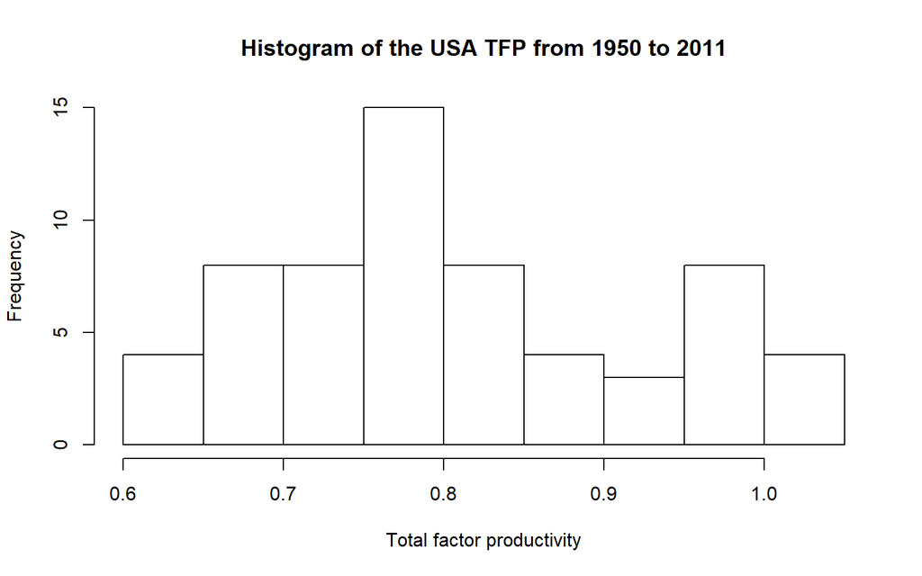

```
## [1] "CAN Variability and Central Tendency values:"
##      rtfpna
##  Min.   :0.8433
##  1st Qu.:0.9733
##  Median :1.0042
##  Mean   :0.9929
##  3rd Qu.:1.0295
##  Max.   :1.0661
## [1] "Standard Deviation: 0.0501257463514977"
```

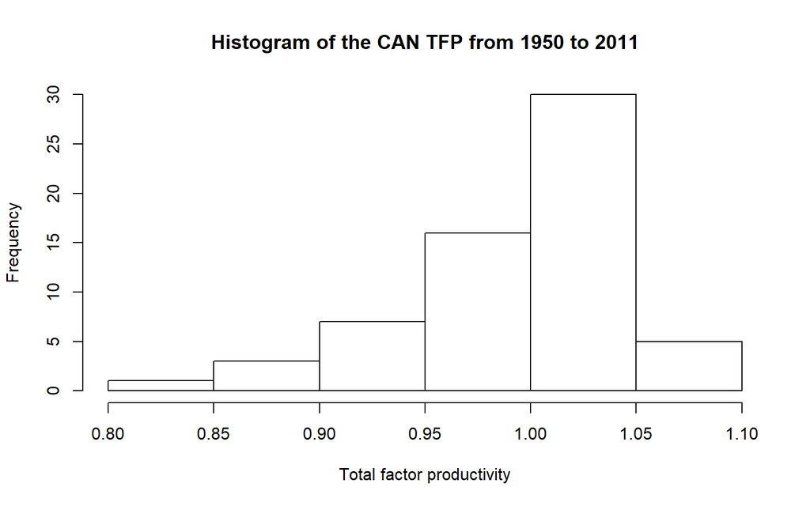

```
## [1] "MEX Variability and Central Tendency values:"
##      rtfpna
##  Min.   :0.7982
##  1st Qu.:1.0122
##  Median :1.0939
##  Mean   :1.1301
##  3rd Qu.:1.2996
##  Max.   :1.3837
## [1] "Standard Deviation: 0.158209043068344"
```

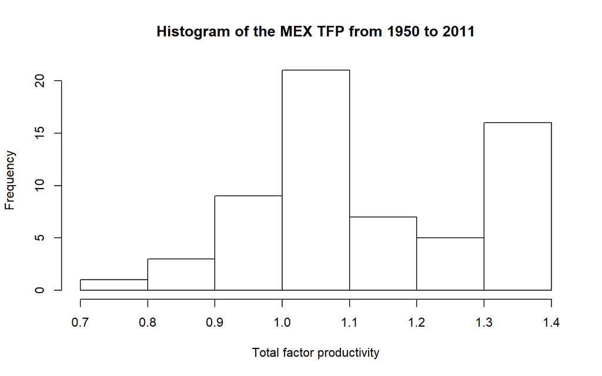

```r
for (i in unique(tfp_nafta$isocode)){

  print(paste0(i, ' Variability and Central Tendency values:'))

  print(summary(select(filter(tfp_nafta,isocode== i),rtfpna)))

  print(paste0('Standard Deviation: ', sd(tfp_nafta[tfp_nafta[,1]==i,3])))

  hist(tfp_nafta[tfp_nafta[,1]==i,3], main = paste0('Histogram of the ', i, ' TFP from 1950 to 2011'), xlab = "Total factor productivity")

}
```

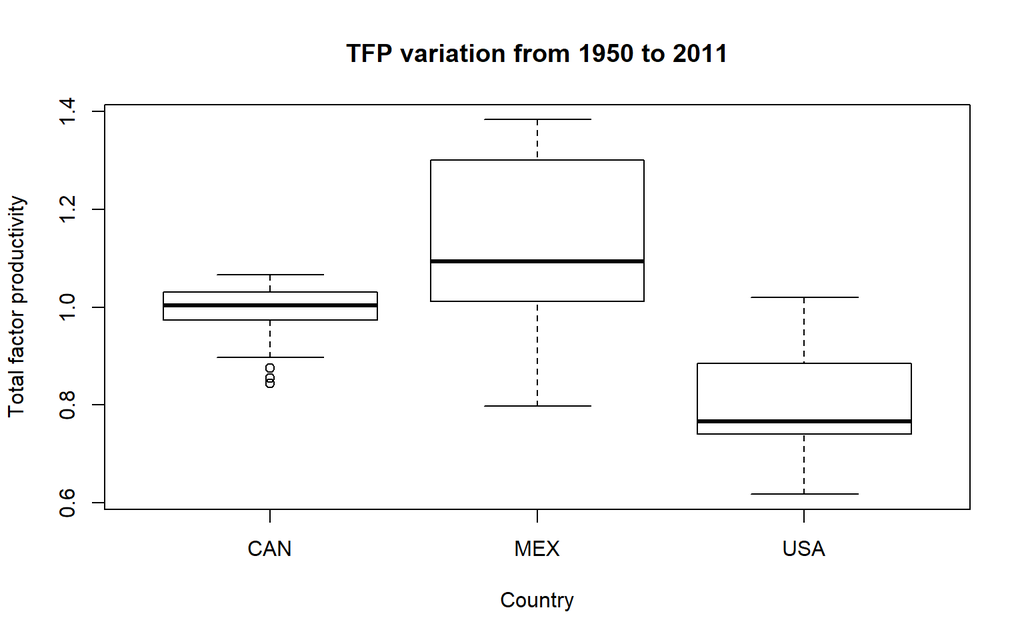

```r
boxplot(tfp_nafta$rtfpna~isocode,data=tfp_nafta, main= "TFP variation from 1950 to 2011",
        xlab="Country", ylab="Total factor productivity")
```

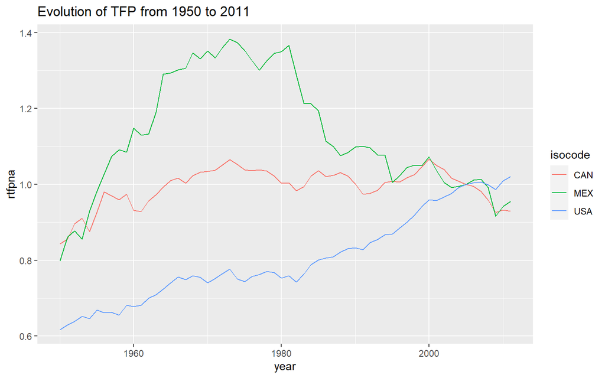

```r
tfp_nafta %>%
  ggplot(aes(x=year, y=rtfpna, group=isocode, color=isocode)) +
  geom_line()+
  ggtitle('Evolution of TFP from 1950 to 2011')
```

```r
# preparing for average growth rate and moving average
wide_tfp_nafta <- spread(tfp_nafta,isocode,rtfpna) %>%
  mutate(CAN_var = (CAN - lag(CAN) / 1) / lag(CAN) * 100,
         MEX_var = (MEX - lag(MEX) / 1) / lag(MEX) * 100,
         USA_var = (USA - lag(USA) / 1) / lag(USA) * 100,
         CAN_ma = ma(CAN,order = 5),
         MEX_ma = ma(MEX,order = 5),
         USA_ma = ma(USA,order = 5))

# average growth rate
kable(sapply(wide_tfp_nafta[,c('CAN_var','MEX_var','USA_var')], mean, na.rm=T), caption = 'Average Growth 1950 to 2011')
```

Average Growth 1950 to 2011

|  | x |
| --- | --- |
| CAN_var | 0.1793220 |
| MEX_var | 0.3504901 |
| USA_var | 0.8384735 |

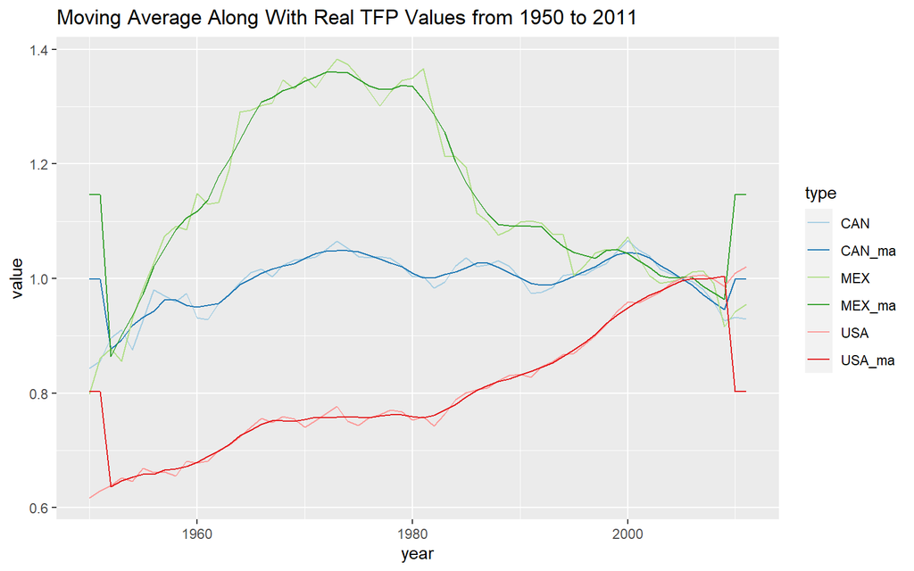

```r
# filling moving average NA values
wide_tfp_nafta[,8:10] <- replace(wide_tfp_nafta[,8:10], TRUE, lapply(wide_tfp_nafta[,8:10], na.aggregate))

#plotting moving average values
gather(wide_tfp_nafta, type, value, CAN:USA_ma, factor_key=FALSE) %>%
  filter(type %in% c('CAN','CAN_ma','USA','USA_ma','MEX','MEX_ma')) %>%
  arrange(type) %>%
  ggplot(aes(x=year, y=value, group=type, color=type)) +
  geom_line()+
  ggtitle('Moving Average Along With Real TFP Values from 1950 to 2011')+
  scale_color_brewer(palette = "Paired")
```

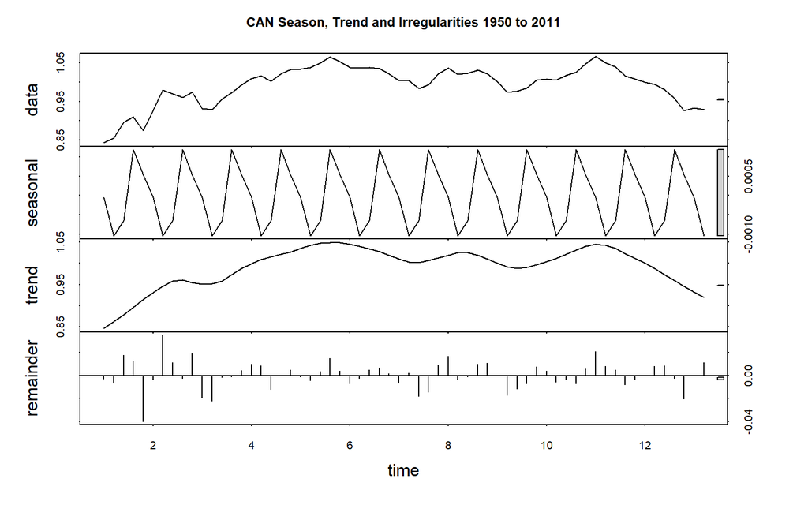

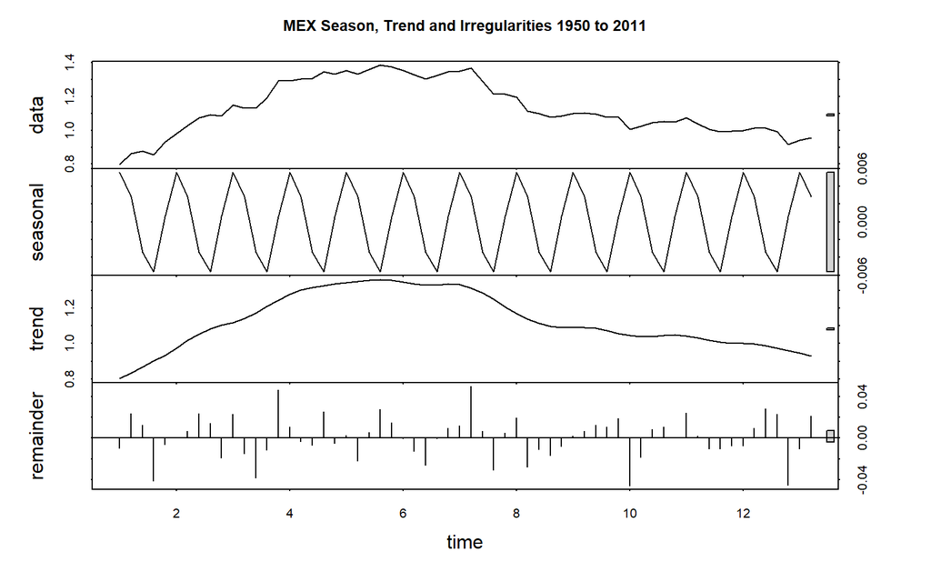

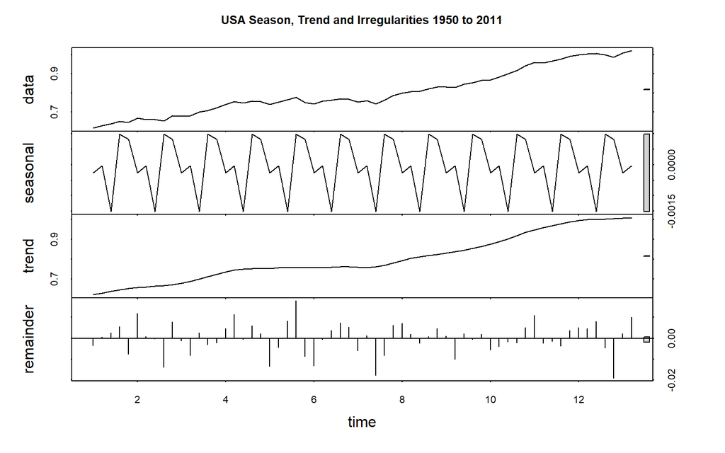

```r
# decomposing and plotting
for (i in c(2,3,4)){

plot(stl(ts(wide_tfp_nafta[,i], frequency = 5), 'periodic'), main=paste0(colnames(wide_tfp_nafta)[i], ' Season, Trend and Irregularities 1950 to 2011'))

}
```

### Forecast 10 years of the series

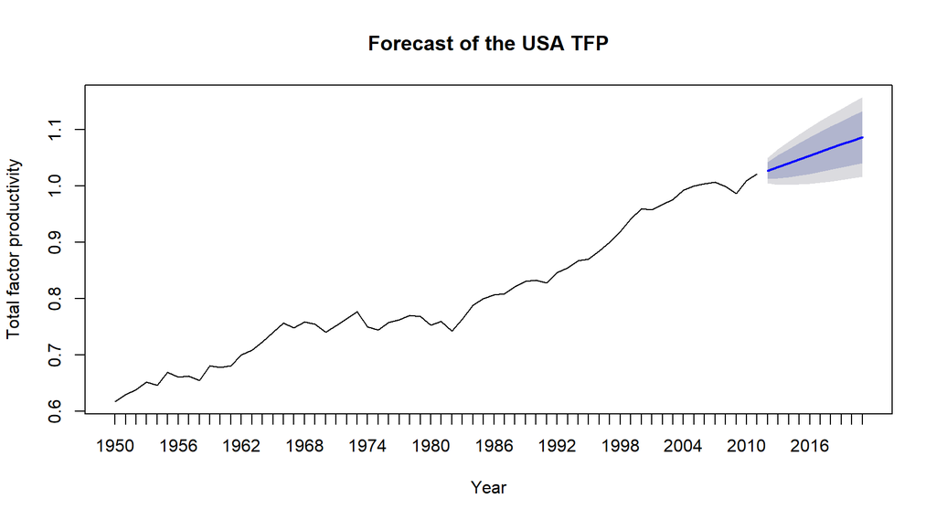

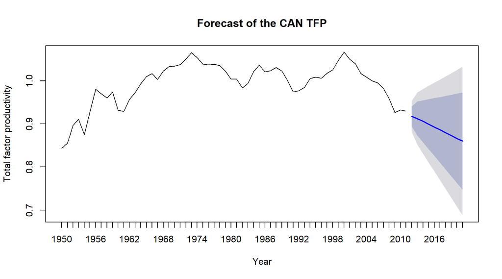

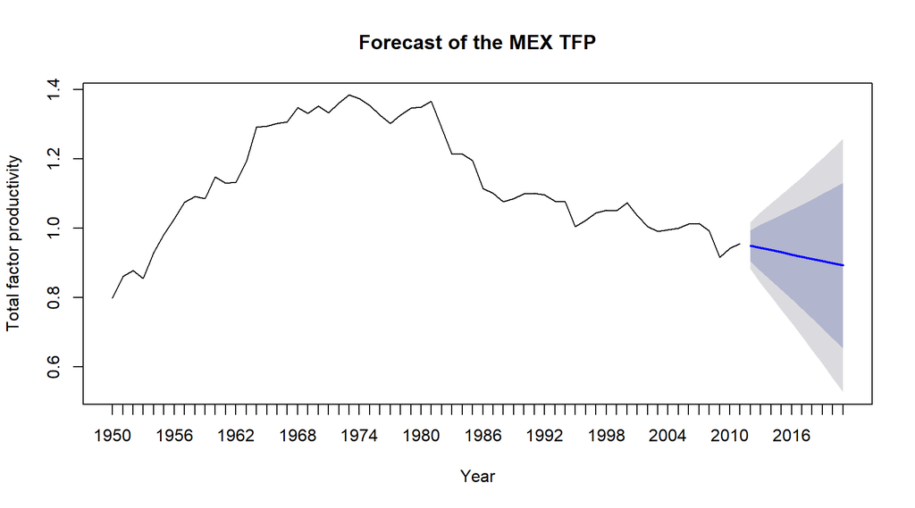

```r
# dataframe to receive the predictions
tfp_prediction <- setNames(data.frame(matrix(nrow = 10, ncol = 4)), c('years','USA','CAN','MEX'))
tfp_prediction$years <- 2011:2020

# predicting, plotting and
for (i in unique(tfp_nafta$isocode)){

  prediction <- forecast(auto.arima(tfp_nafta[tfp_nafta$isocode==i, "rtfpna"]), h = 10)
  tfp_prediction[, i]<- prediction$mean

  plot(forecast(auto.arima(tfp_nafta[tfp_nafta$isocode==i, "rtfpna"]), h = 10),
       main = paste0('Forecast of the ', i, ' TFP'), xlab = 'Year', ylab="Total factor productivity", xaxt= 'n')
  axis(1, at = 1:72, labels = 1950:2021)

}
```

```r
kable(tfp_prediction, caption = "Forecast of the NAFTA Countries 2011 to 2020")
```

| years | USA | CAN | MEX |
| --- | --- | --- | --- |
| 2011 | 1.027002 | 0.9171747 | 0.9494087 |
| 2012 | 1.033613 | 0.9123099 | 0.9430517 |
| 2013 | 1.040223 | 0.9057691 | 0.9366947 |
| 2014 | 1.046834 | 0.8992282 | 0.9303377 |
| 2015 | 1.053445 | 0.8926874 | 0.9239807 |
| 2016 | 1.060055 | 0.8861466 | 0.9176237 |
| 2017 | 1.066666 | 0.8796058 | 0.9112667 |
| 2018 | 1.073276 | 0.8730650 | 0.9049097 |
| 2019 | 1.079887 | 0.8665242 | 0.8985527 |
| 2020 | 1.086497 | 0.8599834 | 0.8921958 |

### Can you think about another feature that could be helpful in explaining TFP series? Explain

Yes. Another important variable that may be an relevant driver to TFP (i.e could be a founder of TFP in terms of causation) is investment in R&D. That is because R&D raises rates of innovation and “enhances technology transfer by improving the ability of firms to learn about advances in the leading edge[…]” Griffith et al. (2004).

# CASE 2

### PRE PROCESSING

```r
trade_br=read.csv('data_comexstat.csv',stringsAsFactors = FALSE)
trade_br$date <- ymd(trade_br$date)
```

### Show the evolution of total monthly and total annual exports from Brazil (all states and to everywhere) of ‘soybeans’, ‘soybean oil’ and ‘soybean meal’

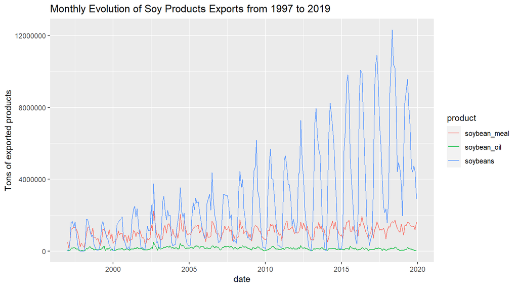

```r
trade_br %>%
  filter(type=='Export') %>%
  filter(product %in% c('soybean_meal', 'soybean_oil', 'soybeans')) %>%
  group_by(date,product) %>%
  summarise(tons=sum(tons)) %>%
  ggplot(aes(x=date, y=tons, group=product, color=product)) +
  geom_line()+
  ggtitle('Monthly Evolution of Soy Products Exports from 1997 to 2019')+
  ylab("Tons of exported products")
```

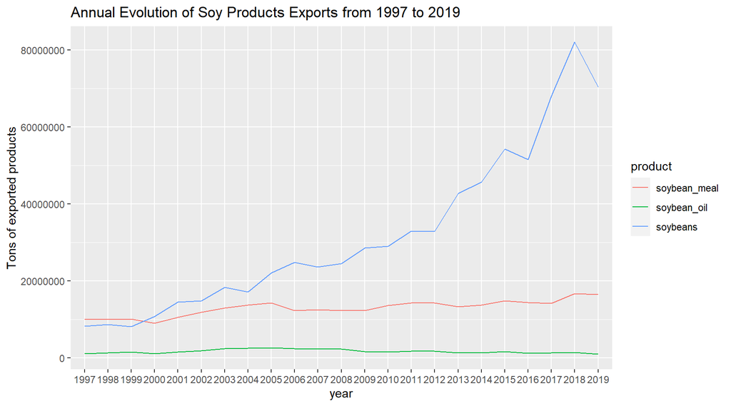

```r
trade_br %>%
  mutate(year = format(date, "%Y")) %>%
  filter(type=='Export') %>%
  filter(product %in% c('soybean_meal', 'soybean_oil', 'soybeans')) %>%
  group_by(year,product) %>%
  summarise(tons=sum(tons)) %>%
  ggplot(aes(x=year, y=tons, group=product, color=product)) +
  geom_line()+
  ggtitle('Annual Evolution of Soy Products Exports from 1997 to 2019') +
  ylab("Tons of exported products")
```

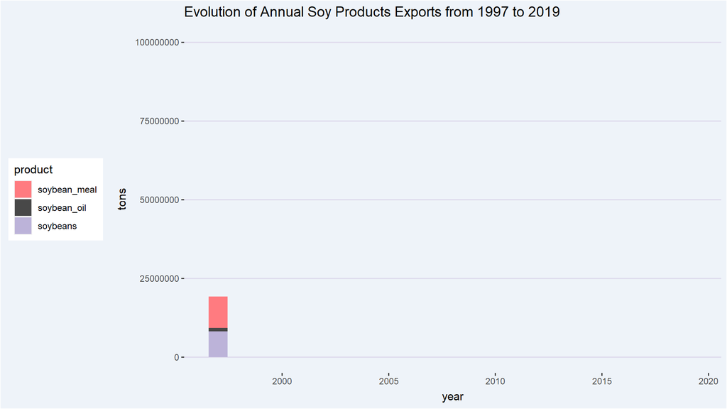

```r
anim <- trade_br %>%
  mutate(year = as.numeric(format(date, "%Y"))) %>%
  filter(type=='Export') %>%
  filter(product %in% c('soybean_meal', 'soybean_oil', 'soybeans')) %>%
  group_by(year,product) %>%
  summarise(tons=sum(tons)) %>%
  ggplot(aes(x=year, y=tons, fill=product))+
  geom_bar(stat="identity")+
  labs(title = 'Evolution of Annual Soy Products Exports from 1997 to 2019')+
  transition_time(year)+
  ease_aes('linear')+
  theme(legend.position = "left")+
  shadow_mark()+
  enter_fade()+
  theme(legend.position = "left",panel.background = element_blank(),plot.background = element_rect(fill = "#EEF3F9"),
        panel.grid = element_blank(), panel.grid.major.y = element_line(color="#DDD9EC"))+
  scale_fill_manual(values = c("#FF7B80","#484848","#BCB3D9"))

animate(anim, fps=19, nframes=200,type = "cairo-png",width = 1920, height= 1080,res=200,
        antialias = "subpixel",end_pause=40, renderer = gifski_renderer())
```

### What are the 3 most important products exported by Brazil in the last 5 years?

When considering only the USD variable, the most important products exported from 2015 to 2019 are soybeans, sugar and soybean meal.

```r
export_br <- trade_br %>%
  mutate(year = as.numeric(format(date, "%Y"))) %>%
  filter(type=='Export' & year>=2015) %>%
  group_by(product) %>%
  summarise(tons=sum(tons),usd=sum(usd))

kable(arrange(export_br,desc(usd)), caption = "Exported Product's performace from 2015 to 2019")
```

Exported Product’s performace from 2015 to 2019

| product | tons | usd |
| --- | --- | --- |
| soybeans | 326331464 | 123325529857 |
| sugar | 120033649 | 40938486021 |
| soybean_meal | 76647488 | 28407723437 |
| corn | 144599338 | 24447720910 |
| soybean_oil | 6711428 | 4795946873 |
| wheat | 3885836 | 726945386 |

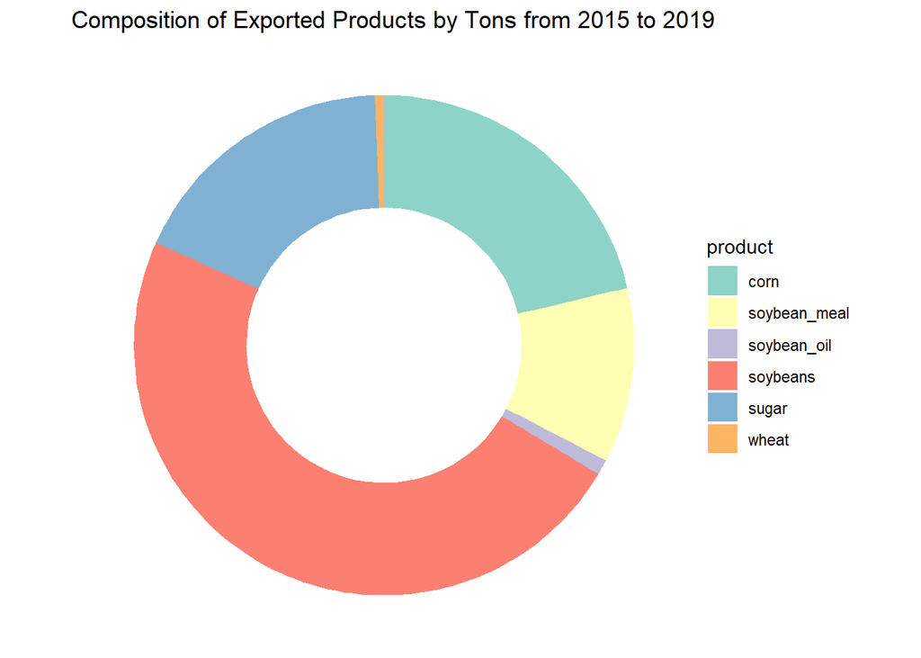

```r
export_br$fraction_usd = export_br$usd / sum(export_br$usd)
export_br$fraction_tons = export_br$tons / sum(export_br$tons)

# Compute the cumulative percentages (top of each rectangle)
export_br$ymax_usd = cumsum(export_br$fraction_usd)
export_br$ymax_tons = cumsum(export_br$fraction_tons)

# Compute the bottom of each rectangle
export_br$ymin_usd = c(0, head(export_br$ymax_usd, n=-1))
export_br$ymin_tons = c(0, head(export_br$ymax_tons, n=-1))


ggplot(export_br, aes(ymax=ymax_tons, ymin=ymin_tons, xmax=4, xmin=3.1, fill=product)) +
  geom_rect() +
  scale_fill_brewer(palette="Set3") +
  coord_polar(theta="y") +
  xlim(c(2, 4)) +
  theme_void() +
  theme(legend.position = "right")+
  ggtitle('Composition of Exported Products by Tons from 2015 to 2019')
```

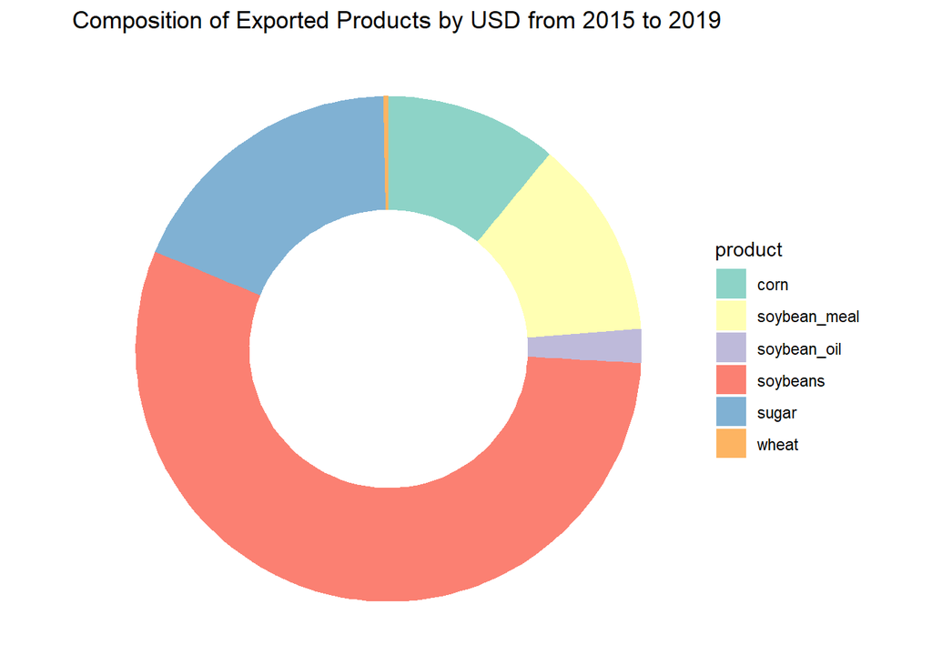

```r
ggplot(export_br, aes(ymax=ymax_usd, ymin=ymin_usd, xmax=4, xmin=3.1, fill=product)) +
  geom_rect() +
  scale_fill_brewer(palette="Set3") +
  coord_polar(theta="y") +
  xlim(c(2, 4)) +
  theme_void() +
  theme(legend.position = "right") +
  ggtitle('Composition of Exported Products by USD from 2015 to 2019')
```

### What are the main routes through which Brazil have been exporting ‘corn’ in the last few years? Are there differences in the relative importance of routes depending on the product?

The main two routes for corn exportation over the past ten years have been sea and river, respectively. For the past 10 years the sea route, by far, played the most significant role for the Brazilian exports. Besides the river route for soybeans and corn, all the other routes have had an insignficant participation in delivering Brazilian products to the rest of the world.

```r
route_corn <- trade_br %>%
  mutate(year = as.numeric(format(date, "%Y"))) %>%
  filter(product=='corn' & type=='Export' & year>=2010) %>%
  group_by(route) %>%
  summarise(tons=sum(tons))

kable(arrange(route_corn,desc(tons)), caption = 'Exporting routes for corn in the last ten years')
```

Exporting routes for corn in the last ten years

| route | tons |
| --- | --- |
| Sea | 222659149.32 |
| River | 8802398.30 |
| Other | 272577.78 |
| Ground | 139944.67 |
| Air | 10698.05 |

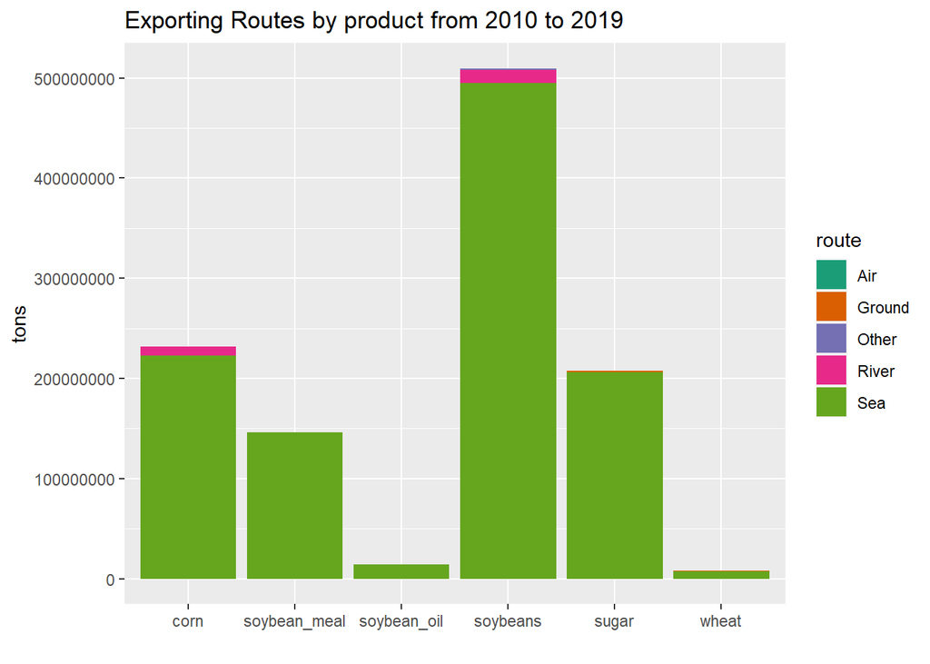

```r
trade_br %>%
  mutate(year = as.numeric(format(date, "%Y"))) %>%
  filter(type=='Export' & year>=2010) %>%
  group_by(product,route) %>%
  summarise(tons=sum(tons)) %>%
  ggplot(aes(fill=route, y=tons, x=product)) +
  geom_bar(position="stack", stat="identity")+
  ggtitle("Exporting Routes by product from 2010 to 2019") +
  xlab("")+
  scale_fill_brewer(palette='Dark2')
```

### Which countries have been the most important trade partners for Brazil in terms of ‘corn’ and ‘sugar’ in the last 3 years?

```r
corn <- trade_br %>%
  mutate(year = as.numeric(format(date, "%Y"))) %>%
  filter(product=='corn' & year >=2017) %>%
  group_by(product,country) %>%
  summarise(tons=sum(tons))

kable(head(arrange(corn[,2:3],desc(tons))),caption = 'Total Amount of Traded Corn From 2017 to 2019')
```

Total Amount of Traded Corn From 2017 to 2019

| country | tons |
| --- | --- |
| Iran | 16425650 |
| Japan | 9676921 |
| Vietnam | 9446982 |
| Egypt | 8353797 |
| Spain | 8243946 |
| South Korea | 6273068 |

```r
sugar <- trade_br %>%
  mutate(year = as.numeric(format(date, "%Y"))) %>%
  filter(product=='sugar' & year >=2017) %>%
  group_by(product,country) %>%
  summarise(tons=sum(tons))

kable(head(arrange(sugar[,2:3],desc(tons))),caption = 'Total Amount of Traded Sugar From 2017 to 2019')
```

Total Amount of Traded Sugar From 2017 to 2019

| country | tons |
| --- | --- |
| Algeria | 6696854 |
| Bangladesh | 6331640 |
| India | 5111372 |
| United Arab Emirates | 4545802 |
| Saudi Arabia | 4249462 |
| Nigeria | 4156814 |

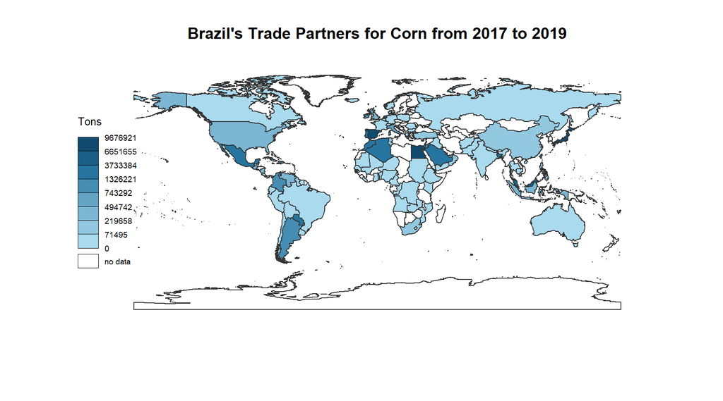

```r
my_spdf <- readOGR(dsn="world_shape_file/TM_WORLD_BORDERS_SIMPL-0.3.shp", verbose=FALSE)

my_spdf@data <- left_join(my_spdf@data, corn[,2:3], by=c('NAME'='country'))
my_spdf@data <- left_join(my_spdf@data, sugar[,2:3], by=c('NAME'='country'))

choroLayer(spdf = my_spdf, df = my_spdf, var = "tons.x",legend.pos = 'left',legend.title.txt = 'Tons',method = 'kmeans')
title("Brazil's Trade Partners for Corn from 2017 to 2019")
```

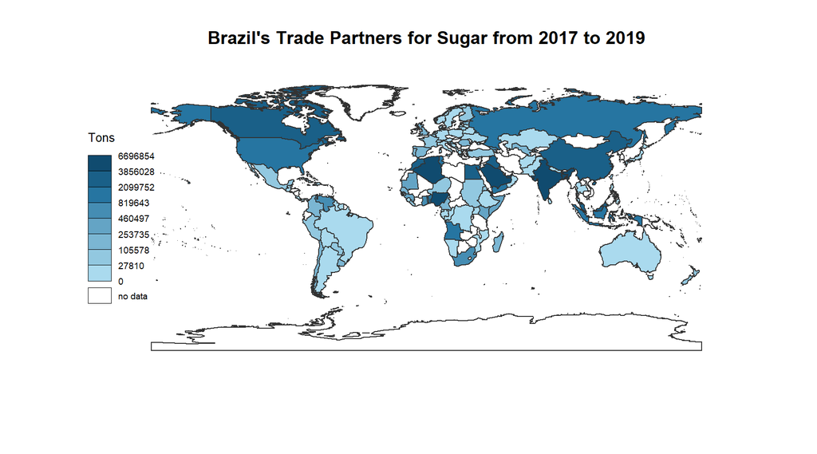

```r
choroLayer(spdf = my_spdf, df = my_spdf, var = "tons.y",legend.pos = 'left',legend.title.txt = 'Tons',method = 'kmeans')
title("Brazil's Trade Partners for Sugar from 2017 to 2019")
```

### For each of the products in the dataset, show the 5 most important states in terms of exports?

```r
export_top_states <- trade_br %>%
  filter(type=='Export') %>%
  group_by(product,state) %>%
  summarise(tons=sum(tons)) %>%
  top_n(n=5,tons)

DT::datatable(export_top_states,caption = 'Total Amount of Traded Corn From 2017 to 2019')
```

|  | product | state | tons |
| --- | --- | --- | --- |
| 1 | corn | GO | 28464620.48 |
| 2 | corn | MS | 18270595.193 |
| 3 | corn | MT | 151823361.829 |
| 4 | corn | PR | 53862465.979 |
| 5 | corn | SP | 7343888.098 |
| 6 | soybean_meal | BA | 17368055.631 |
| 7 | soybean_meal | GO | 28686580.483 |
| 8 | soybean_meal | MT | 79462274.743 |
| 9 | soybean_meal | PR | 86392369.404 |
| 10 | soybean_meal | RS | 48927458.589 |

[output cut: 20 more lines]

```r
export_state <- trade_br %>%
  filter(type=='Export') %>%
  group_by(product,state) %>%
  summarise(tons=sum(tons))

nodes <- data.frame(name=c(as.character(export_state$product), as.character(export_state$state)) %>% unique())

export_state$product <- match(export_state$product, nodes$name)-1
export_state$state <-  match(export_state$state, nodes$name)-1

ColourScal ='d3.scaleOrdinal() .range(["#FDE725FF","#B4DE2CFF","#6DCD59FF","#35B779FF","#1F9E89FF","#26828EFF","#31688EFF","#3E4A89FF","#482878FF","#440154FF"])'

sankeyNetwork(Links = export_state, Nodes = nodes,
              Source = "product", Target = "state",
              Value = "tons", NodeID = "name",
              sinksRight=FALSE, colourScale=ColourScal, nodeWidth=40, fontSize=13, nodePadding=20, height = 900, width = 900)
```

[interactive chart not shown]

### What should be the total brazilian soybeans, soybean_meal, and corn export forecasts, in tons, for the next 11 years (2020-2030)?

All forecasts were made using models built on multiple linear regressions in combination with ARIMA. Common Machine Learning methods have no awareness of time dimensions, that is why in this case, simply applying them would not result in a reasonable prediction as the question involve time series data. Even though it is a relatively simple model in comparison with the other models such as boosting, deep learning or even regression trees, the model have been proven a fair performance for the data provided. It is true that the predictions made present a steady growth throughout the years (except for corn and soybean meal in 2020), because the covariates provided evolve in constants rates within the period of time to be predicted. Moreover, the models are based on regression tuned by backward elimination, in other words, the independent variables present a correlation with the dependent variable, and no more than that. For further discussions, a model built on causation diagrams together with data from observational studies and reduction of biases may provide a better understanding of the Brazilian exports’ performance and, thus, a more accurate model.

### PRE PROCESSING

```r
# loading covariates data
covariates <- read.xlsx('covariates.xlsx')
```

```r
############ CORN


# total amount of corn per year
corn_total_exported <- trade_br %>%
  mutate(year = as.numeric(format(date, "%Y"))) %>%
  filter(product=='corn') %>%
  group_by(year) %>%
  summarise(tons=sum(tons))

#joining covariates and amount of corn per year. also, keeping data from 1997 to 2019
dataset <- left_join(covariates,corn_total_exported, by=c('year'='year')) %>%
  filter(between(year, 1997, 2019))


# manually differencing the time series
# plot.ts(diff(dataset$tons, differences=1), main='stationary time series')
# acf(diff(dataset$tons, differences=1), main='correlogram')
# pacf(diff(dataset$tons, differences=1), main='partial correlogram')

mlr_summary <-  lm(formula = tons ~ .,
               data = select(dataset, -c(1,10,12,11,8,7,3,13,5,2,4)))

summary(mlr_summary)
```

```
##
## Call:
## lm(formula = tons ~ ., data = select(dataset, -c(1, 10, 12, 11,
##     8, 7, 3, 13, 5, 2, 4)))
##
## Residuals:
##      Min       1Q   Median       3Q      Max
## -9651660 -1180825   151678  2264855  5090256
##
## Coefficients:
##               Estimate Std. Error t value       Pr(>|t|)
## (Intercept)  -17316604    3921986  -4.415       0.000267 ***
## gdp_iran       -306271      58772  -5.211 0.000042381482 ***
## gdp_thailand    156368      14520  10.769 0.000000000897 ***
## ---
## Signif. codes:  0 '***' 0.001 '**' 0.01 '*' 0.05 '.' 0.1 ' ' 1
##
## Residual standard error: 3338000 on 20 degrees of freedom
## Multiple R-squared:  0.9301, Adjusted R-squared:  0.9231
## F-statistic: 133.1 on 2 and 20 DF,  p-value: 0.000000000002779
```

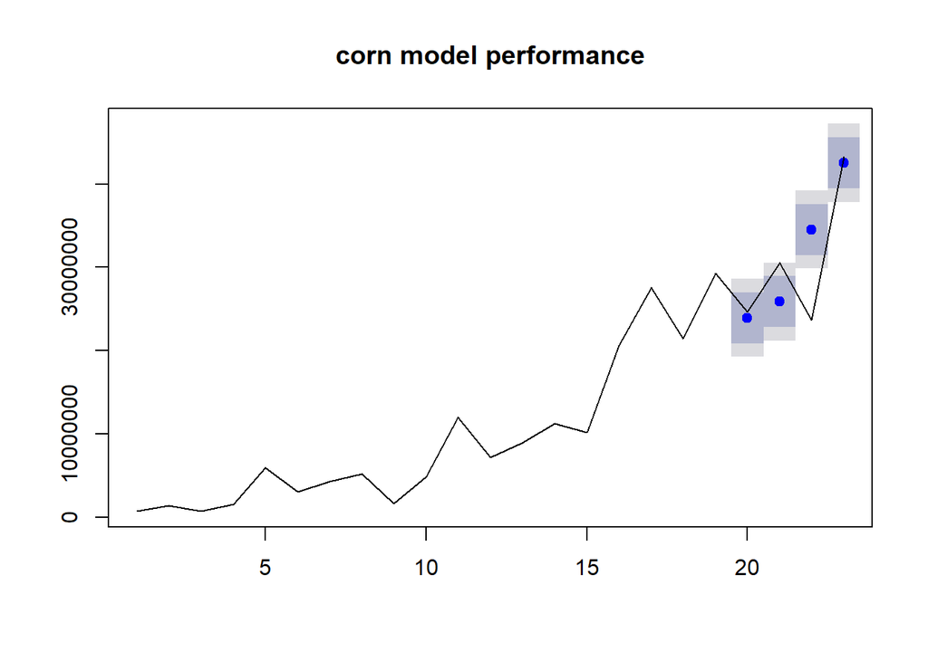

```r
#training and testing model performance
regressor <- auto.arima(ts(dataset[1:19,14]), xreg = as.matrix(select(dataset,c('gdp_iran','gdp_thailand'))[1:19,]))
plot(forecast(regressor,xreg = as.matrix(select(dataset,c('gdp_iran','gdp_thailand'))[20:23,])), main = 'corn model performance')
lines(ts(dataset$tons))
```

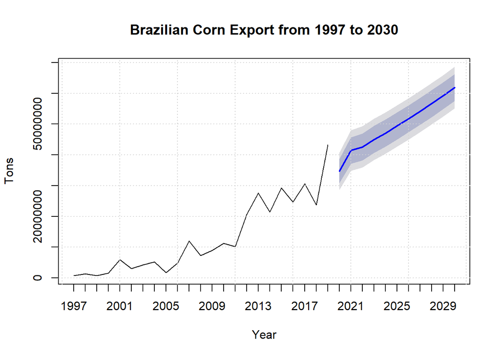

```r
#training the final model
regressor <- auto.arima(ts(dataset$tons), xreg = as.matrix(select(dataset,c('gdp_iran','gdp_thailand'))))

# creating a different dataset for the years to be predicted
dataset_pred <- left_join(covariates, corn_total_exported, by=c('year'='year'))
dataset_pred <- dataset_pred %>%
  filter(year>2019)

# deploying the model
prediction <- forecast(regressor, xreg = as.matrix(select(dataset_pred,c('gdp_iran','gdp_thailand'))))

corn_pred <- setNames(data.frame(prediction$mean),nm = c('corn'))



# plotting the model
plot(prediction,
     main = 'Brazilian Corn Export from 1997 to 2030', xlab = 'Year', ylab="Tons", xaxt='n')
axis(1, at = 1:34, labels = 1997:2030)
grid()
```

```r
######### SOYBEAN_MEAL

# total amount of soybean_meal per year
soybean_meal_total_exported <- trade_br %>%
  mutate(year = as.numeric(format(date, "%Y"))) %>%
  filter(product=='soybean_meal') %>%
  group_by(year) %>%
  summarise(tons=sum(tons))

#joining covariates and amount of soybean_meal per year. also, keeping data from 1997 to 2019
dataset <- left_join(covariates,soybean_meal_total_exported, by=c('year'='year')) %>%
  filter(between(year, 1997, 2019))


# manually differencing the time series
# plot.ts(diff(dataset$tons, differences=1), main='stationary time series')
# acf(diff(dataset$tons, differences=1), main='correlogram')
# pacf(diff(dataset$tons, differences=1), main='partial correlogram')

mlr_summary = lm(formula = tons ~ .,
               data = select(dataset, -c(1,7,2,11,6,3,4,10,8,12)))

summary(mlr_summary)
```

```
##
## Call:
## lm(formula = tons ~ ., data = select(dataset, -c(1, 7, 2, 11,
##     6, 3, 4, 10, 8, 12)))
##
## Residuals:
##      Min       1Q   Median       3Q      Max
## -1448932  -546708   -18970   634395  1217952
##
## Coefficients:
##              Estimate Std. Error t value Pr(>|t|)
## (Intercept)   -466111    2644699  -0.176   0.8620
## gdp_china       -8160       2626  -3.107   0.0058 **
## gdp_thailand    22678       9026   2.512   0.0212 *
## gdp_vietnam     25207       9824   2.566   0.0189 *
## ---
## Signif. codes:  0 '***' 0.001 '**' 0.01 '*' 0.05 '.' 0.1 ' ' 1
##
## Residual standard error: 864400 on 19 degrees of freedom
## Multiple R-squared:  0.8354, Adjusted R-squared:  0.8094
## F-statistic: 32.14 on 3 and 19 DF,  p-value: 0.00000012
```

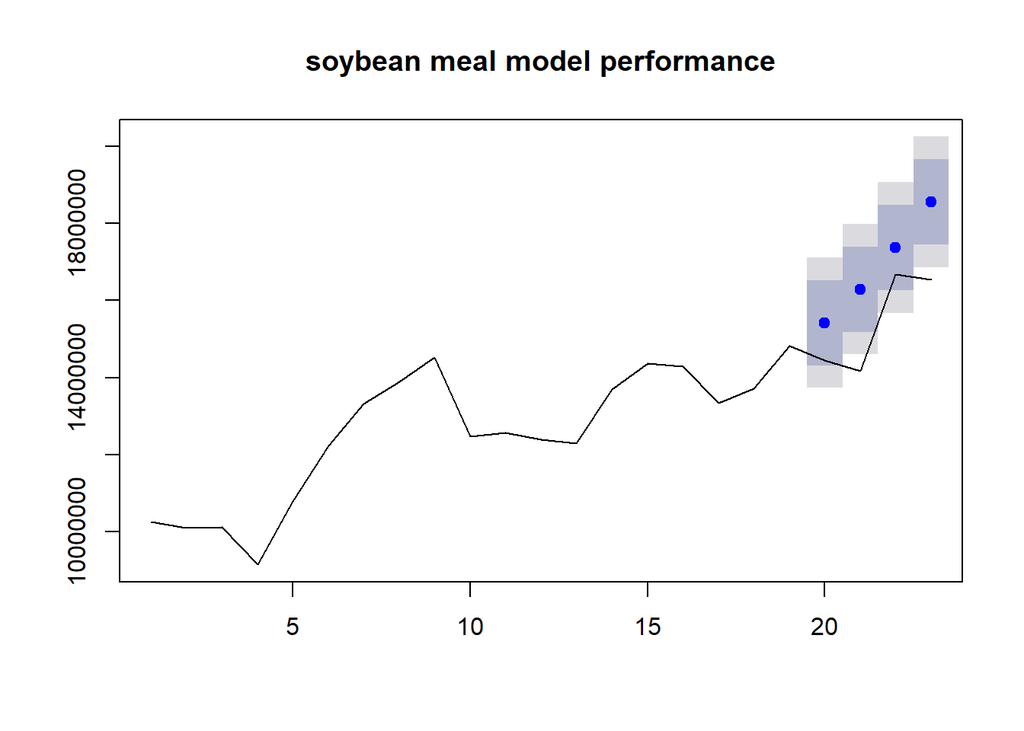

```r
#training and testing model performance
regressor <- auto.arima(ts(dataset[1:19,14]), xreg = as.matrix(select(dataset,c('gdp_china', 'gdp_vietnam', 'gdp_thailand'))[1:19,]))
plot(forecast(regressor,xreg = as.matrix(select(dataset,c('gdp_china', 'gdp_vietnam', 'gdp_thailand'))[20:23,])), main = 'soybean meal model performance')
lines(ts(dataset$tons))
```

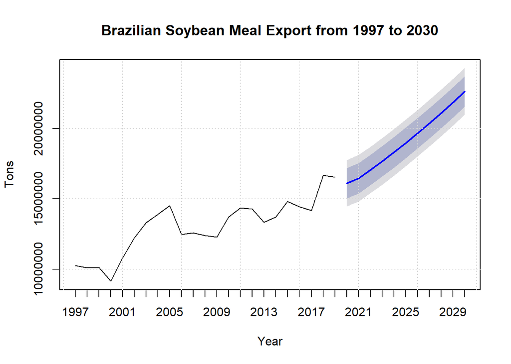

```r
#training the final model
regressor <- auto.arima(ts(dataset$tons), xreg = as.matrix(select(dataset,c('gdp_china', 'gdp_vietnam', 'gdp_thailand'))))

# creating a different dataset for the years to be predicted
dataset_pred <- left_join(covariates, soybean_meal_total_exported, by=c('year'='year'))
dataset_pred <- dataset_pred %>%
  filter(year>2019)

# deploying the model
prediction <- forecast(regressor, xreg = as.matrix(select(dataset_pred,c('gdp_china', 'gdp_vietnam', 'gdp_thailand'))))

soybeanmeal_pred <- setNames(data.frame(prediction$mean),nm = c('soybean meal'))

# plotting the model
plot(prediction,
     main = 'Brazilian Soybean Meal Export from 1997 to 2030', xlab = 'Year', ylab="Tons", xaxt='n')
axis(1, at = 1:34, labels = 1997:2030)
grid()
```

```r
######### soybeans

# total amount of soybeans per year
soybeans_total_exported <- trade_br %>%
  mutate(year = as.numeric(format(date, "%Y"))) %>%
  filter(product=='soybeans') %>%
  group_by(year) %>%
  summarise(tons=sum(tons))

#joining covariates and amount of soybeans per year. also, keeping data from 1997 to 2019
dataset <- left_join(covariates,soybeans_total_exported, by=c('year'='year')) %>%
  filter(between(year, 1997, 2019))


# manually differencing the time series
# plot.ts(diff(dataset$tons, differences=1), main='stationary time series')
# acf(diff(dataset$tons, differences=1), main='correlogram')
# pacf(diff(dataset$tons, differences=1), main='partial correlogram')

mlr_summary = lm(formula = tons ~ .,
               data = select(dataset, -c(1,7,8,11,5,3,10,6,9,12,4)))

summary(mlr_summary)
```

```
##
## Call:
## lm(formula = tons ~ ., data = select(dataset, -c(1, 7, 8, 11,
##     5, 3, 10, 6, 9, 12, 4)))
##
## Residuals:
##      Min       1Q   Median       3Q      Max
## -7328149 -1582293  -571905  1261530 11524901
##
## Coefficients:
##                 Estimate Std. Error t value            Pr(>|t|)
## (Intercept)    -11343014    2699406  -4.202            0.000439 ***
## price_soybeans    -81426      25087  -3.246            0.004049 **
## gdp_vietnam        82063       3895  21.069 0.00000000000000399 ***
## ---
## Signif. codes:  0 '***' 0.001 '**' 0.01 '*' 0.05 '.' 0.1 ' ' 1
##
## Residual standard error: 4039000 on 20 degrees of freedom
## Multiple R-squared:  0.9665, Adjusted R-squared:  0.9631
## F-statistic: 288.5 on 2 and 20 DF,  p-value: 0.000000000000001782
```

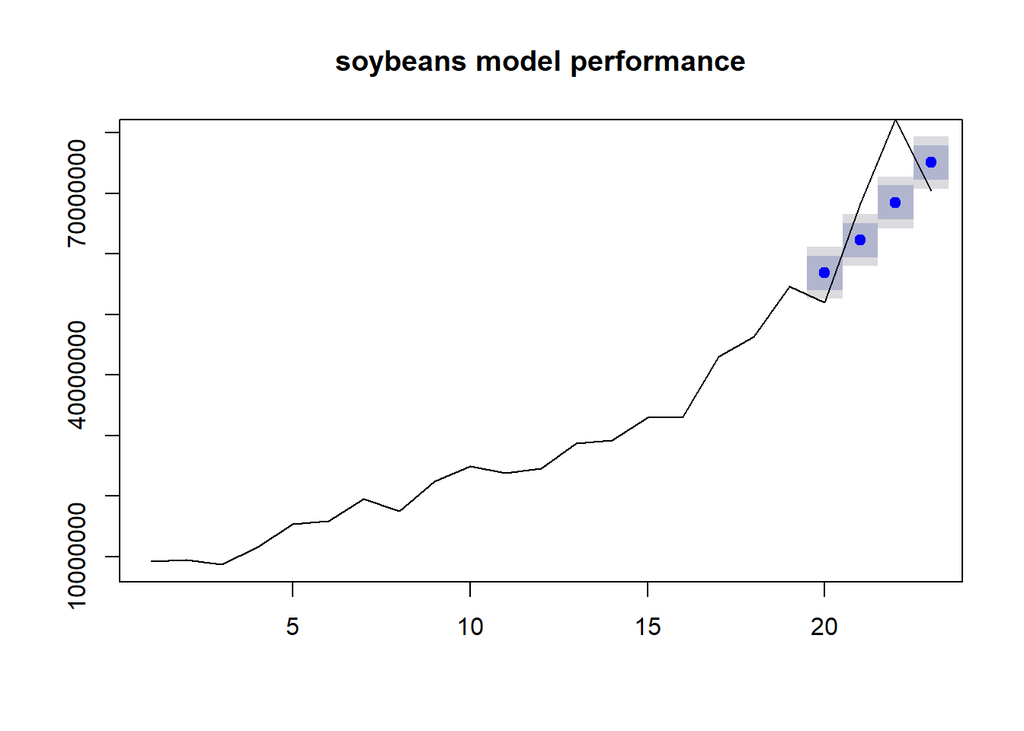

```r
#training and testing model performance
regressor <- auto.arima(ts(dataset[1:19,14]), xreg = as.matrix(select(dataset,c('price_soybeans', 'gdp_vietnam'))[1:19,]))
plot(forecast(regressor,xreg = as.matrix(select(dataset,c('price_soybeans', 'gdp_vietnam'))[20:23,])), main = 'soybeans model performance')
lines(ts(dataset$tons))
```

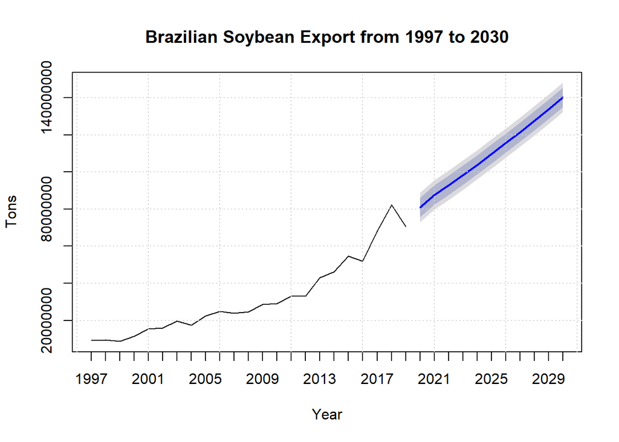

```r
#training the final model
regressor <- auto.arima(ts(dataset$tons), xreg = as.matrix(select(dataset,c('price_soybeans', 'gdp_vietnam'))))

# creating a different dataset for the years to be predicted
dataset_pred <- left_join(covariates, soybeans_total_exported, by=c('year'='year'))
dataset_pred <- dataset_pred %>%
  filter(year>2019)

# deploying the model
prediction <- forecast(regressor, xreg = as.matrix(select(dataset_pred,c('price_soybeans', 'gdp_vietnam'))))


soybeans_pred <- setNames(data.frame(prediction$mean),nm = c('Soybeans'))

# plotting the model
plot(prediction,
     main = 'Brazilian Soybean Export from 1997 to 2030', xlab = 'Year', ylab="Tons", xaxt='n')
axis(1, at = 1:34, labels = 1997:2030)
grid()
```

```r
years <- 2020:2030

df_predict <- data.frame(years, corn_pred, soybeanmeal_pred, soybeans_pred)
df_predict <- mutate(df_predict, total = apply(df_predict[,2:4],1,sum))

kable(df_predict, caption = 'Forecast: Brazilian Exports from 2020 to 2030 by tons')
```

Forecast: Brazilian Exports from 2020 to 2030 by tons

| years | corn | soybean.meal | Soybeans | total |
| --- | --- | --- | --- | --- |
| 2020 | 34741916 | 16109967 | 80964987 | 131816869 |
| 2021 | 41421270 | 16471472 | 87747275 | 145640017 |
| 2022 | 42586760 | 17058613 | 92945800 | 152591173 |
| 2023 | 45030518 | 17670380 | 98300199 | 161001096 |
| 2024 | 47060054 | 18313626 | 103927399 | 169301080 |
| 2025 | 49418370 | 18985373 | 109714976 | 178118719 |
| 2026 | 51740308 | 19675745 | 115627650 | 187043703 |
| 2027 | 54160215 | 20380813 | 121567871 | 196108899 |
| 2028 | 56649412 | 21110895 | 127656601 | 205416909 |
| 2029 | 59239488 | 21867015 | 133887606 | 214994109 |
| 2030 | 61910696 | 22647050 | 140253938 | 224811685 |

### References

Griffith, R., Redding, S., & Reenen, J. V. (2004). Mapping the two faces of R&D: Productivity growth in a panel of OECD industries. Review of economics and statistics, 86(4), 883-895.  
Pearl, J., & Mackenzie, D. (2018). The book of why: the new science of cause and effect. Basic Books.